# RCT Tumor Size Comparison

## Kruskal-Wallis

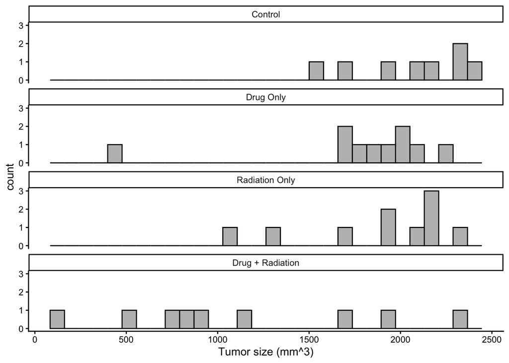

```r
# check conditions
tumor %>%
  ggplot(aes(x = Size)) +
  geom_histogram(color="black", fill="gray") +
  facet_wrap(. ~ Treatment, nrow = 4) +
  theme_classic() +
  labs(x = "Tumor size (mm^3)")
```

```r
# run test
kruskal.test(Size ~ Treatment, data = tumor)
```

```
##
##  Kruskal-Wallis rank sum test
##
## data:  Size by Treatment
## Kruskal-Wallis chi-squared = 9.5212, df = 3, p-value = 0.02311
```

Description:

**Hypothesis:** Null = The median tumor size of all groups is the same; Alternative = At least one of the groups has a different median tumor size.

**Conditions for Kruskal-Wallis test:** 1. k independent populations, 2. Random samples from each of the k populations, and 3. Population distributions have the same shape. The shape of the population distributions was seemingly different, but I proceeded with the analysis to produce a result that can be compared with that of the ANOVA.

**P-value, decision, and conclusion:** The Kruskal-Wallis chi-squared value is 9.5212 in df = 3. The p-value is 0.02, which is smaller than the alpha level of 0.05. Thus, we have evidence to reject the null hypothesis. In conclusion, at least one of the groups has a different median tumor size.

**Agreement with an ANOVA result:** The result is consistent with the ANOVA test.